# FS20C4 - Steinschlag

Fernando Millan Villalobos

February 2020

# 1 Notes

This report was generated on 2020-05-22 15:50:48. R version: 4.0.0 on x86_64-w64-mingw32. For this report, CRAN packages as of 2020-04-01 were used.

## 1.1 R-Script & data

The preprocessing and analysis of the data was conducted in the [R project for statistical computing](https://www.r-project.org/). The RMarkdown script used to generate this document and all the resulting data can be downloaded [under this link](https://github.com/fernandomillanvillalobos/fs20c4_steinschlagrisiko). Through executing `main.Rmd`, the herein described process can be reproduced and this document can be generated. In the course of this, data from the folder `input` will be processed and results will be written to `output`. The html on-line version of the analysis can be accessed through this [link](https://fernandomillanvillalobos.github.io/fs20c4_steinschlagrisiko/).

## 1.2 GitHub

The code for the herein described process can also be freely downloaded from https://github.com/fernandomillanvillalobos/fs20c4_steinschlagrisiko.

## 1.3 Data description of output files

### 1.3.1 `probability_car_hit.csv`

| hour | events | cars_danger_zone_per_hour |
| --- | --- | --- |
| 0 | 2 | 114.66559 |
| 1 | 2 | 53.51061 |
| 2 | 3 | 38.22186 |

# 2 Set up

```
## [1] "package package:rstudioapi detached"
```

```
## [1] "package package:knitr detached"
```

## 2.1 Define packages

```r
# from https://mran.revolutionanalytics.com/web/packages/\
# checkpoint/vignettes/using-checkpoint-with-knitr.html
# if you don't need a package, remove it from here (commenting not sufficient)
# tidyverse: see https://blog.rstudio.org/2016/09/15/tidyverse-1-0-0/
cat("
library(rstudioapi)
library(tidyverse) # ggplot2, dplyr, tidyr, readr, purrr, tibble, magrittr, readxl
library(scales) # scales for ggplot2
library(jsonlite) # json
library(MASS) # advanced statistics
library(lintr) # code linting
library(sf) # spatial data handling
library(rmarkdown)
library(cowplot) # theme
library(extrafont)", # fonts
file = "manifest.R")
```

## 2.2 Install packages

```r
# if checkpoint is not yet installed, install it (for people using this
# system for the first time)
if (!require(checkpoint)) {
  if (!require(devtools)) {
    install.packages("devtools", repos = "http://cran.us.r-project.org")
    require(devtools)
  }
  devtools::install_github("RevolutionAnalytics/checkpoint",
                           ref = "v0.3.2", # could be adapted later,
                           # as of now (beginning of July 2017
                           # this is the current release on CRAN)
                           repos = "http://cran.us.r-project.org")
  require(checkpoint)
}
# nolint start
if (!dir.exists("~/.checkpoint")) {
  dir.create("~/.checkpoint")
}
# nolint end
# install packages for the specified CRAN snapshot date
checkpoint(snapshotDate = package_date,
           project = path_to_wd,
           verbose = T,
           scanForPackages = T,
           use.knitr = F,
           R.version = r_version)
rm(package_date)
```

## 2.3 Load packages

```r
source("manifest.R")
unlink("manifest.R")
```

## 2.4 Load additional scripts

```r
# if you want to outsource logic to other script files, see README for
# further information
# Load all visualizations functions as separate scripts
knitr::read_chunk("scripts/dviz.supp.R")
source("scripts/dviz.supp.R")
knitr::read_chunk("scripts/themes.R")
source("scripts/themes.R")
knitr::read_chunk("scripts/plot_grid.R")
source("scripts/plot_grid.R")
knitr::read_chunk("scripts/align_legend.R")
source("scripts/align_legend.R")
knitr::read_chunk("scripts/label_log10.R")
source("scripts/label_log10.R")
```

# 3 Introduction

This notebook is thought as a working document for the development and documentation of the [FS20C4 - Steinschlag project](https://ds-spaces.technik.fhnw.ch/app/uploads/sites/17/2019/09/hs19c4steinschlag-3.pdf)).

As requested by the village of Schiers (GR), a cursory review of the potential rockfall hazard was performed. This study was conducted to assist the village in determining potential rockfall and setting mitigation actions that can be useful to avoid closure of a section of the roadway that connects Schiers with the outside world. The investigation consisted of a data analysis and a probability calculation carried on by a hired data scientist. The area of study covered the natural bedrock outcrops above the roadway. Protection methods are put into play once rocks have started to destabilize. Typically, rockfall events are mitigated in one of two ways: either passive or active mitigation. In the case of passive mitigations, these cover only the effects of the rockfall and they are generally used in the deposition or run-out zones. Using mesh cable nets to catch falling rocks and contain them as to avoid any damage to the area below represent such a scenario. These methods, also called mitigation efforts, are directed towards avoidance, stabilization, protection and management of risk.

# 4 Data Importing

Originally two different datasets containing rockfalls data (day, hour, mass and speed), one per mountain side, were provided for our analysis [Dataset 1](https://www.dropbox.com/s/i58gdv6pzi03rhr/out_1.csv?dl=0), [Dataset 2](https://www.dropbox.com/s/3nk9pv7nzz8f0qb/out_2.csv?dl=0). More data were necessary to know the traffic density within 24 hours in the area. This data come from the report [**Mikrozensus Mobilität und Verkehr 2015**](https://www.bfs.admin.ch/bfs/de/home/statistiken/mobilitaet-verkehr/personenverkehr/verkehrsverhalten.assetdetail.1840604.html) by the Bundesamt für Statistik (BFS). We must point out that the density traffic data per hour available were collected and summarized at national level not at local level. The table with the used data can be found [here](https://www.bfs.admin.ch/bfs/de/home/statistiken/mobilitaet-verkehr/personenverkehr/verkehrsverhalten/tabellen-2015/hauptbericht.assetdetail.2500421.html).

```r
# Import datasets
data01 <- read_csv("input/out_1.csv")
data02 <- read_csv("input/out_2.csv")
data_traffic <- read_csv2("input/tagesverlauf_verkehrsmittel_2015.csv")
```

```
## Using ',' as decimal and '.' as grouping mark. Use read_delim() for more control.
```

```r
# Select columns and rows we are interesting in with values different as na´s
(data01 <- data01 %>%
  dplyr::select(1:4) %>%
  na.omit())
```

| Datum | Uhrzeit | Masse [kg] | Geschwindigkeit [m/s] |
| --- | --- | --- | --- |
| 2019-01-01 | 09:00:00 | 194 | 8.4 |
| 2019-01-01 | 21:00:00 | 224 | 8.8 |
| 2019-01-02 | 14:00:00 | 3104 | 9.2 |
| 2019-01-04 | 15:00:00 | 228 | 8.0 |
| 2019-01-05 | 23:00:00 | 755 | 7.0 |
| 2019-01-08 | 16:00:00 | 215 | 6.5 |
| 2019-01-10 | 10:00:00 | 300 | 7.9 |
| 2019-01-11 | 08:00:00 | 1019 | 10.4 |
| 2019-01-13 | 08:00:00 | 1288 | 10.8 |
| 2019-01-15 | 05:00:00 | 344 | 10.0 |
| 2019-01-17 | 14:00:00 | 707 | 6.0 |
| 2019-01-17 | 18:00:00 | 938 | 10.2 |
| 2019-01-18 | 01:00:00 | 79 | 6.9 |
| 2019-01-20 | 03:00:00 | 260 | 11.2 |
| 2019-01-23 | 08:00:00 | 220 | 9.1 |
| 2019-01-23 | 10:00:00 | 253 | 10.1 |
| 2019-01-23 | 14:00:00 | 2177 | 7.6 |
| 2019-01-24 | 02:00:00 | 827 | 8.5 |
| 2019-01-24 | 04:00:00 | 208 | 11.2 |
| 2019-01-25 | 04:00:00 | 79 | 9.4 |
| 2019-01-26 | 20:00:00 | 1456 | 7.1 |
| 2019-01-27 | 10:00:00 | 464 | 7.8 |
| 2019-01-31 | 16:00:00 | 1131 | 6.4 |
| 2019-02-03 | 03:00:00 | 140 | 12.6 |
| 2019-02-04 | 12:00:00 | 274 | 10.3 |
| 2019-02-05 | 03:00:00 | 12 | 8.8 |
| 2019-02-05 | 04:00:00 | 419 | 10.9 |
| 2019-02-06 | 14:00:00 | 292 | 8.4 |
| 2019-02-08 | 12:00:00 | 169 | 6.5 |
| 2019-02-08 | 12:00:00 | 308 | 9.0 |
| 2019-02-09 | 23:00:00 | 3040 | 10.4 |
| 2019-02-10 | 04:00:00 | 454 | 7.1 |
| 2019-02-11 | 20:00:00 | 554 | 8.7 |
| 2019-02-12 | 17:00:00 | 524 | 4.3 |
| 2019-02-15 | 13:00:00 | 123 | 9.7 |
| 2019-02-15 | 18:00:00 | 214 | 10.8 |
| 2019-02-17 | 09:00:00 | 74 | 9.7 |
| 2019-02-17 | 12:00:00 | 845 | 4.7 |
| 2019-02-18 | 03:00:00 | 567 | 8.2 |
| 2019-02-20 | 13:00:00 | 218 | 7.3 |
| 2019-02-21 | 00:00:00 | 609 | 12.4 |
| 2019-02-23 | 12:00:00 | 404 | 10.7 |
| 2019-02-23 | 20:00:00 | 1042 | 10.5 |
| 2019-02-23 | 21:00:00 | 294 | 9.8 |
| 2019-02-25 | 22:00:00 | 1917 | 9.5 |
| 2019-02-26 | 17:00:00 | 1175 | 9.6 |
| 2019-02-26 | 23:00:00 | 1315 | 3.6 |
| 2019-03-01 | 15:00:00 | 873 | 6.3 |
| 2019-03-01 | 19:00:00 | 505 | 8.6 |
| 2019-03-01 | 21:00:00 | 191 | 10.8 |
| 2019-03-02 | 21:00:00 | 236 | 8.7 |
| 2019-03-04 | 23:00:00 | 129 | 8.3 |
| 2019-03-07 | 10:00:00 | 555 | 8.2 |
| 2019-03-07 | 14:00:00 | 401 | 9.5 |
| 2019-03-07 | 19:00:00 | 440 | 9.5 |
| 2019-03-10 | 12:00:00 | 286 | 8.4 |
| 2019-03-10 | 18:00:00 | 154 | 11.6 |
| 2019-03-11 | 13:00:00 | 463 | 7.3 |
| 2019-03-11 | 20:00:00 | 539 | 14.1 |
| 2019-03-12 | 18:00:00 | 2040 | 11.9 |
| 2019-03-12 | 19:00:00 | 460 | 6.9 |
| 2019-03-17 | 12:00:00 | 185 | 6.5 |
| 2019-03-17 | 12:00:00 | 422 | 10.0 |
| 2019-03-18 | 16:00:00 | 167 | 8.9 |
| 2019-03-22 | 18:00:00 | 2847 | 7.0 |
| 2019-03-26 | 00:00:00 | 44 | 8.9 |
| 2019-03-26 | 06:00:00 | 45 | 8.4 |
| 2019-03-27 | 16:00:00 | 312 | 5.8 |

```r
(data02 <- data02 %>%
  dplyr::select(1:4) %>%
  na.omit())
```

| Date | Uhrzeit | m [kg] | v [m/s] |
| --- | --- | --- | --- |
| 2019-01-01 | 09:00:00 | 38 | 45.4 |
| 2019-01-03 | 06:00:00 | 187 | 41.6 |
| 2019-01-04 | 10:00:00 | 36 | 44.6 |
| 2019-01-07 | 14:00:00 | 6 | 41.2 |
| 2019-01-11 | 06:00:00 | 65 | 39.6 |
| 2019-01-11 | 16:00:00 | 58 | 33.2 |
| 2019-01-14 | 11:00:00 | 365 | 40.2 |
| 2019-01-16 | 02:00:00 | 22 | 46.5 |
| 2019-01-18 | 06:00:00 | 146 | 36.2 |
| 2019-01-19 | 17:00:00 | 29 | 38.3 |
| 2019-01-20 | 22:00:00 | 40 | 41.6 |
| 2019-01-21 | 11:00:00 | 304 | 36.7 |
| 2019-01-22 | 21:00:00 | 33 | 44.1 |
| 2019-01-29 | 07:00:00 | 50 | 40.0 |
| 2019-02-06 | 02:00:00 | 77 | 38.0 |
| 2019-02-10 | 20:00:00 | 76 | 39.2 |
| 2019-02-14 | 05:00:00 | 138 | 33.2 |
| 2019-02-15 | 11:00:00 | 152 | 24.9 |
| 2019-02-16 | 18:00:00 | 241 | 40.6 |
| 2019-02-25 | 14:00:00 | 97 | 30.0 |
| 2019-02-28 | 05:00:00 | 37 | 32.2 |
| 2019-02-28 | 12:00:00 | 64 | 34.3 |
| 2019-03-07 | 21:00:00 | 55 | 31.7 |
| 2019-03-10 | 16:00:00 | 0 | 32.3 |
| 2019-03-10 | 23:00:00 | 45 | 32.2 |
| 2019-03-11 | 18:00:00 | 406 | 44.1 |
| 2019-03-17 | 09:00:00 | 58 | 33.6 |
| 2019-03-20 | 10:00:00 | 16 | 42.1 |
| 2019-03-21 | 13:00:00 | 211 | 29.0 |
| 2019-03-24 | 16:00:00 | 3 | 42.3 |
| 2019-03-25 | 14:00:00 | 63 | 43.2 |
| 2019-03-28 | 01:00:00 | 58 | 37.2 |

```r
(data_traffic <- data_traffic %>%
  dplyr::select(c(1, 8)))
```

| X1 | Auto |
| --- | --- |
| 0-1 Uhr | 1.5 |
| 1-2 Uhr | 0.7 |
| 2-3 Uhr | 0.5 |
| 3-4 Uhr | 0.4 |
| 4-5 Uhr | 1.0 |
| 5-6 Uhr | 3.4 |
| 6-7 Uhr | 9.2 |
| 7-8 Uhr | 12.2 |
| 8-9 Uhr | 11.1 |
| 9-10 Uhr | 12.0 |
| 10-11 Uhr | 12.3 |
| 11-12 Uhr | 14.3 |
| 12-13 Uhr | 12.9 |
| 13-14 Uhr | 14.2 |
| 14-15 Uhr | 13.1 |
| 15-16 Uhr | 13.9 |
| 16-17 Uhr | 17.4 |
| 17-18 Uhr | 19.5 |
| 18-19 Uhr | 15.6 |
| 19-20 Uhr | 11.1 |
| 20-21 Uhr | 7.1 |
| 21-22 Uhr | 5.6 |
| 22-23 Uhr | 4.8 |
| 23-24 Uhr | 3.0 |

# 5 Data Pre-Processing

In this step we are going to transform our imported data in a way that allows us to apply further analysis. Typically, this process requires some data wrangling, data transformation and the creation of new variables.

```r
# Rename columns
names(data01) <- c("date", "time", "mass", "speed")
names(data02) <- c("date", "time", "mass", "speed")
names(data_traffic) <- c("hour", "pct_traffic")

# Parse hour column
hours <- str_split_fixed(data_traffic$hour, " ", n = 2)[, 1] # get the hours interval
hour <- str_split_fixed(hours, "-", n = 2)[, 1] # get the hours starting at 0h.
data_traffic[, 1] <- hour # replace old values with new ones
(data_traffic[, 1] <- as.integer(data_traffic$hour)) # parse as integer
```

```
##  [1]  0  1  2  3  4  5  6  7  8  9 10 11 12 13 14 15 16 17 18 19 20 21 22 23
```

```r
# Calculating kinetic energy (kJ)
ke <- function(m, s) {
  x <- m
  y <- s
  return(round(.5 * x * y ** 2 / 1000, 5))
}
data01$energy_kJ <- ke(data01$mass, data01$speed) # adding variable energy to data01
data02$energy_kJ <- ke(data02$mass, data02$speed) # adding variable energy to data02

# Checking the data

# Checking if there´s any NA
sum(is.na(data01))
```

```
## [1] 0
```

```r
sum(is.na(data02))
```

```
## [1] 0
```

```r
# A quick look at the dataframe let us spot a mass value equal to 0 in dataset 02. Let´s check it for both datasets.
sum(data01$mass == 0)
```

```
## [1] 0
```

```r
sum(data02$mass == 0)
```

```
## [1] 1
```

```r
# It seems there´s a mass value equal to 0 in dataset 02. As we know that a rock muss have certain weight,
# we get rid off this value and keep the rest of the data.
data02 <-subset(data02, mass != 0)
sum(data02$mass == 0)
```

```
## [1] 0
```

```r
# Now we turn our eyes to the data_traffic dataset.
sum(data_traffic$pct_traffic)
```

```
## [1] 216.8
```

```r
# Traffic_density data is scaled to 216.8 percent and needs to be scaled down to 100 percent
data_traffic <- mutate(data_traffic, pct_traffic = pct_traffic / 2.168)
sum(data_traffic$pct_traffic)
```

```
## [1] 100
```

# 6 Exploratory Data Analysis (EDA)

## 6.1 Data Summarization

Now we want to describe some important properties of the distribution of the values across the observations in our datasets, an overview of the key properties of the data.

```r
# Finding the most common value of our different variables in our two samples.
summary(data01)
```

```
##       date                time               mass            speed
##  Min.   :2019-01-01   Length:68         Min.   :  12.0   Min.   : 3.600
##  1st Qu.:2019-01-23   Class1:hms        1st Qu.: 214.8   1st Qu.: 7.300
##  Median :2019-02-13   Class2:difftime   Median : 402.5   Median : 8.800
##  Mean   :2019-02-12   Mode  :numeric    Mean   : 628.6   Mean   : 8.788
##  3rd Qu.:2019-03-02                     3rd Qu.: 773.0   3rd Qu.:10.125
##  Max.   :2019-03-27                     Max.   :3104.0   Max.   :14.100
##    energy_kJ
##  Min.   :  0.4646
##  1st Qu.:  8.2149
##  Median : 12.8151
##  Mean   : 25.1978
##  3rd Qu.: 23.1360
##  Max.   :164.4032
```

```r
summary(data02)
```

```
##       date                time               mass           speed
##  Min.   :2019-01-01   Length:31         Min.   :  3.0   Min.   :24.90
##  1st Qu.:2019-01-17   Class1:hms        1st Qu.: 37.5   1st Qu.:33.40
##  Median :2019-02-10   Class2:difftime   Median : 58.0   Median :39.20
##  Mean   :2019-02-10   Mode  :numeric    Mean   :102.5   Mean   :37.97
##  3rd Qu.:2019-03-08                     3rd Qu.:142.0   3rd Qu.:41.85
##  Max.   :2019-03-28                     Max.   :406.0   Max.   :46.50
##    energy_kJ
##  Min.   :  2.684
##  1st Qu.: 29.800
##  Median : 40.000
##  Mean   : 73.908
##  3rd Qu.: 67.421
##  Max.   :394.796
```

```r
# Adding  the variance, the sample standard deviation and the inter-quartile range (IQR).
dplyr::select(data01, c(mass, speed, energy_kJ)) %>%
  summarise_each(funs(var, sd, IQR))
```

| mass_var | speed_var | energy_kJ_var | mass_sd | speed_sd | energy_kJ_sd | mass_IQR | speed_IQR | energy_kJ_IQR |
| --- | --- | --- | --- | --- | --- | --- | --- | --- |
| 484255.5 | 3.956875 | 1069.613 | 695.8847 | 1.989189 | 32.70493 | 558.25 | 2.825 | 14.92106 |

```r
dplyr::select(data02, c(mass, speed, energy_kJ)) %>%
  summarise_each(funs(var, sd, IQR))
```

| mass_var | speed_var | energy_kJ_var | mass_sd | speed_sd | energy_kJ_sd | mass_IQR | speed_IQR | energy_kJ_IQR |
| --- | --- | --- | --- | --- | --- | --- | --- | --- |
| 10853.19 | 29.04759 | 7841.356 | 104.1786 | 5.389582 | 88.55143 | 104.5 | 8.45 | 37.62085 |

## 6.2 Data Visualization

We´re going to explore and gain insights from our data using one of the most outstanding ability of human beings: capturing visual patterns. Let´s explore distributions of variables in our two datasets: mass, speed and energy.

### 6.2.1 Mass Distribution

As we can see in the chart, the most common rockfalls from our dataset 01 are the ones that involves rocks of 500Kg. or less. Events of rock than more than 1500Kg. are rare. Regarding dataset 02, we notice that falling rocks are significant lighter than in the opposite slope. Most common rockfalls are up to 100Kg.

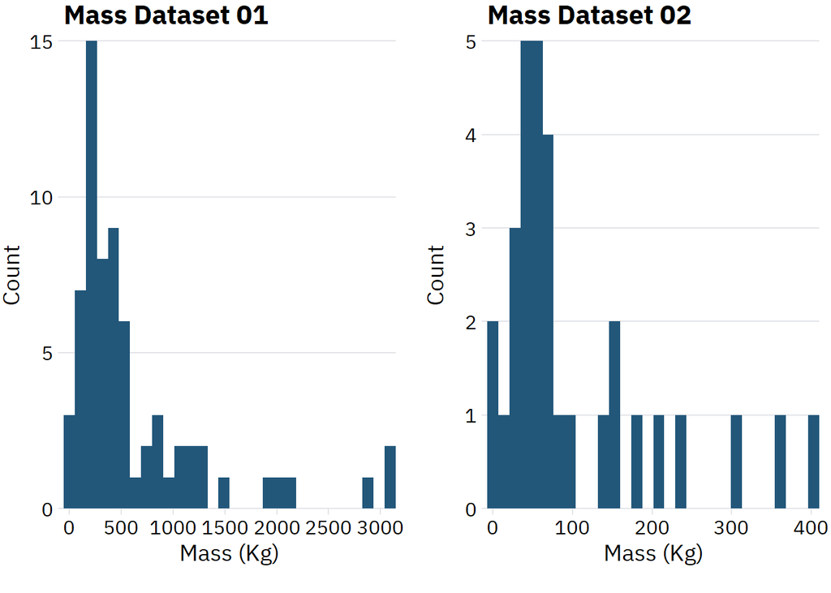

```r
# Chart data01
p1 <- ggplot(data = data01, aes(x = mass)) +
  geom_histogram(bins = 30, fill = "#22577a") +
  scale_y_continuous(name = "Count", expand = c(0, 0)) +
  scale_x_continuous(name = "Mass (Kg)", breaks = c(seq(0, 3500, 500)), expand = c(0, 0)) +
  labs(title = "Mass Dataset 01") +
  coord_cartesian(clip = "off") +
  theme_dviz_hgrid() +
  theme(
    axis.line.x = element_blank(),
    plot.margin = margin(3, 7, 3, 1.5)
  )

# Chart data02
p2 <- ggplot(data = data02, aes(x = mass)) +
  geom_histogram(bins = 30, fill = "#22577a") +
  scale_y_continuous(name = "Count", expand = c(0, 0)) +
  scale_x_continuous(name = "Mass (Kg)", breaks = c(seq(0, 550, 100)), expand = c(0, 0)) +
  labs(title = "Mass Dataset 02") +
  coord_cartesian(clip = "off") +
  theme_dviz_hgrid() +
  theme(
    axis.line.x = element_blank(),
    plot.margin = margin(3, 7, 3, 1.5)
  )

# Plot datasets side by side to ease an overview
plot_grid(
  p1, NULL, p2,
  NULL, NULL, NULL,
  align = 'hv',
  rel_widths = c(1, .04, 1),
  rel_heights = c(1, .04, 1)
)
```

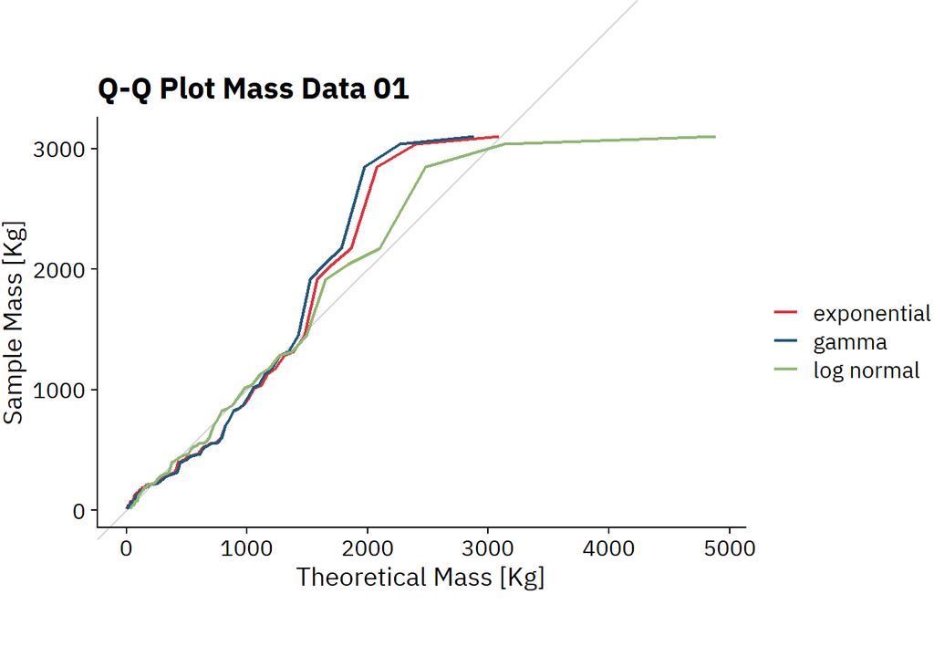

```r
# Now we want to determine to what extent the observed data points do or do not follow a given distribution. We do that for our both datasets available.

# For data01
expo_fit_mass_data01 <- fitdistr(data01$mass, "exponential")
gamma_fit_mass_data01 <- fitdistr(data01$mass, "gamma")
lognorm_fit_mass_data01 <- fitdistr(data01$mass, "lognormal")

# For data02
expo_fit_mass_data02 <- fitdistr(data02$mass, "exponential")
gamma_fit_mass_data02 <- fitdistr(data02$mass, "gamma")
lognorm_fit_mass_data02 <- fitdistr(data02$mass, "lognormal")

# Q-Q Plots

# Q-Q Plot Data01
p3 <- ggplot(data01, aes(sample = mass)) +
  geom_abline(slope = 1, intercept = 0, color = "#d4d6dd") +
  stat_qq(distribution = qexp,
          dparams = list(expo_fit_mass_data01$estimate[1]),
          geom = "line",
          aes(color = "exponential"),
          size = .8) +
  stat_qq(distribution = qgamma,
          dparams = list(gamma_fit_mass_data01$estimate[1], gamma_fit_mass_data01$estimate[2]),
          geom = "line",
          aes(color = "gamma"),
          size = .8) +
  stat_qq(distribution = qlnorm,
          dparams = list(lognorm_fit_mass_data01$estimate[1], lognorm_fit_mass_data01$estimate[2]),
          geom = "line",
          aes(color = "log normal"),
          size = .8) +
  scale_color_manual(name = "",
                     values = c("exponential" = "#df3340",
                                "gamma" = "#22577a",
                                "log normal" = "#90b673"),
                     breaks = c("exponential",
                                "gamma",
                                "log normal")) +
  labs(title = "Q-Q Plot Mass Data 01", x = "Theoretical Mass [Kg]", y = "Sample Mass [Kg]") +
  coord_fixed(clip = "off") +
  theme_dviz_open()
p3
```

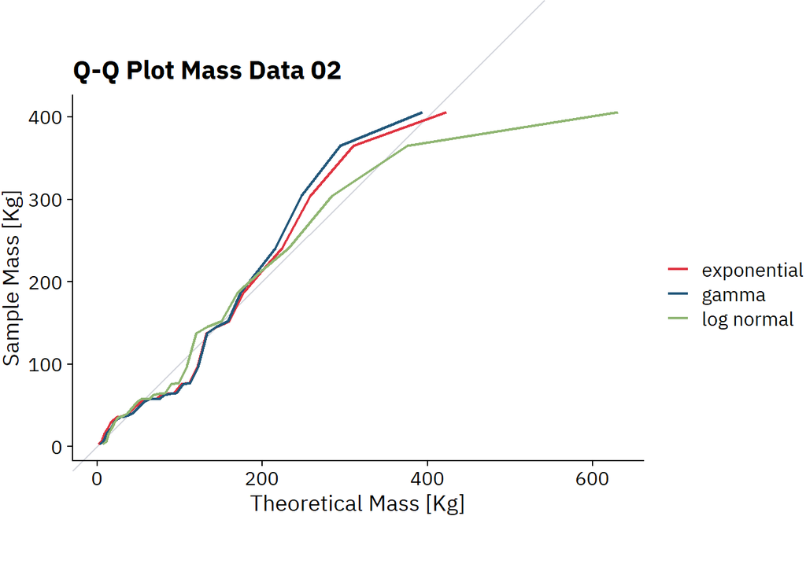

```r
# Q-Q Plot Data02
p4 <- ggplot(data02, aes(sample = mass)) +
  geom_abline(slope = 1, intercept = 0, color = "#d4d6dd") +
  stat_qq(distribution = qexp,
          dparams = list(expo_fit_mass_data02$estimate[1]),
          geom = "line",
          aes(color = "exponential"),
          size = .8) +
  stat_qq(distribution = qgamma,
          dparams = list(gamma_fit_mass_data02$estimate[1], gamma_fit_mass_data02$estimate[2]),
          geom = "line",
          aes(color = "gamma"),
          size = .8) +
  stat_qq(distribution = qlnorm,
          dparams = list(lognorm_fit_mass_data02$estimate[1], lognorm_fit_mass_data02$estimate[2]),
          geom = "line",
          aes(color = "log normal"),
          size = .8) +
  scale_color_manual(name = "",
                     values = c("exponential" = "#df3340",
                                "gamma" = "#22577a",
                                "log normal" = "#90b673"),
                     breaks = c("exponential",
                                "gamma",
                                "log normal")) +
  labs(title = "Q-Q Plot Mass Data 02", x = "Theoretical Mass [Kg]", y = "Sample Mass [Kg]") +
  coord_fixed(clip = "off") +
  theme_dviz_open()
p4
```

### 6.2.2 Speed Distribution

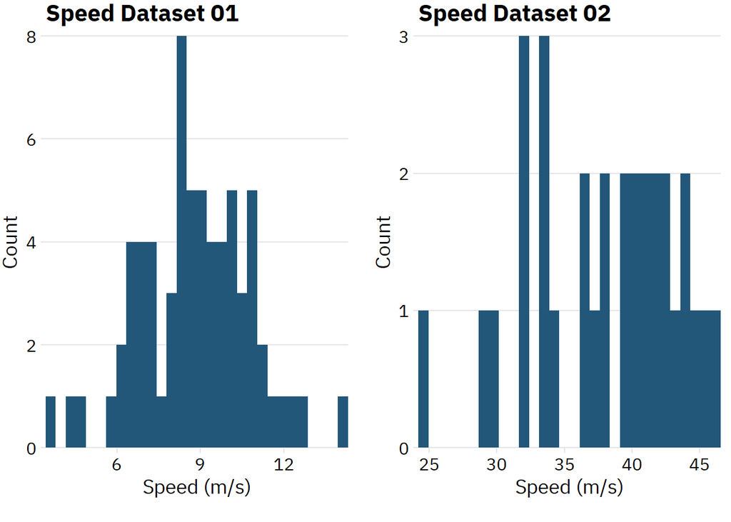

```r
# Chart data01
p1 <- ggplot(data = data01, aes(x = speed)) +
  geom_histogram(bins = 30, fill = "#22577a") +
  scale_y_continuous(name = "Count", expand = c(0, 0)) +
  scale_x_continuous(name = "Speed (m/s)", breaks = c(seq(0, 15, 3)), expand = c(0, 0)) +
  labs(title = "Speed Dataset 01") +
  coord_cartesian(clip = "off") +
  theme_dviz_hgrid() +
  theme(
    axis.line.x = element_blank(),
    plot.margin = margin(3, 7, 3, 1.5)
  )

# Chart data02
p2 <- ggplot(data = data02, aes(x = speed)) +
  geom_histogram(bins = 30, fill = "#22577a") +
  scale_y_continuous(name = "Count", expand = c(0, 0)) +
  scale_x_continuous(name = "Speed (m/s)", breaks = c(seq(0, 55, 5)), expand = c(0, 0)) +
  labs(title = "Speed Dataset 02") +
  coord_cartesian(clip = "off") +
  theme_dviz_hgrid() +
  theme(
    axis.line.x = element_blank(),
    plot.margin = margin(3, 7, 3, 1.5)
  )

plot_grid(
  p1, NULL, p2,
  NULL, NULL, NULL,
  align = 'hv',
  rel_widths = c(1, .04, 1),
  rel_heights = c(1, .04, 1)
)
```

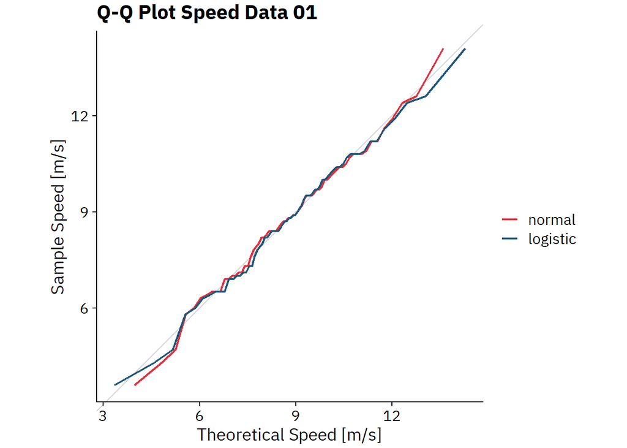

```r
# Now we want to determine to what extent the observed data points do or do not follow a given distribution. We do that for our both datasets available.

# For data01
norm_fit_speed_data01 <- fitdistr(data01$speed, "normal")
logistic_fit_speed_data01 <- fitdistr(data01$speed, "logistic")

# For data02
norm_fit_speed_data02 <- fitdistr(data02$speed, "normal")
logistic_fit_speed_data02 <- fitdistr(data02$speed, "logistic")

# Q-Q Plot Data01
p3 <- ggplot(data01, aes(sample = speed)) +
  geom_abline(slope = 1, intercept = 0, color = "#d4d6dd") +
  stat_qq(distribution = qnorm,
          dparams = list(norm_fit_speed_data01$estimate[1], norm_fit_speed_data01$estimate[2]),
          geom = "line",
          aes(color = "normal"),
          size = .8) +
  stat_qq(distribution = qlogis,
          dparams = list(logistic_fit_speed_data01$estimate[1], logistic_fit_speed_data01$estimate[2]),
          geom = "line",
          aes(color = "logistic"),
          size = .8) +
  scale_color_manual(name = "",
                     values = c("normal" = "#df3340",
                                "logistic" = "#22577a"),
                     breaks = c("normal",
                                "logistic")) +
  labs(title = "Q-Q Plot Speed Data 01", x = "Theoretical Speed [m/s]", y = "Sample Speed [m/s]") +
  coord_fixed(clip = "off") +
  theme_dviz_open()
p3
```

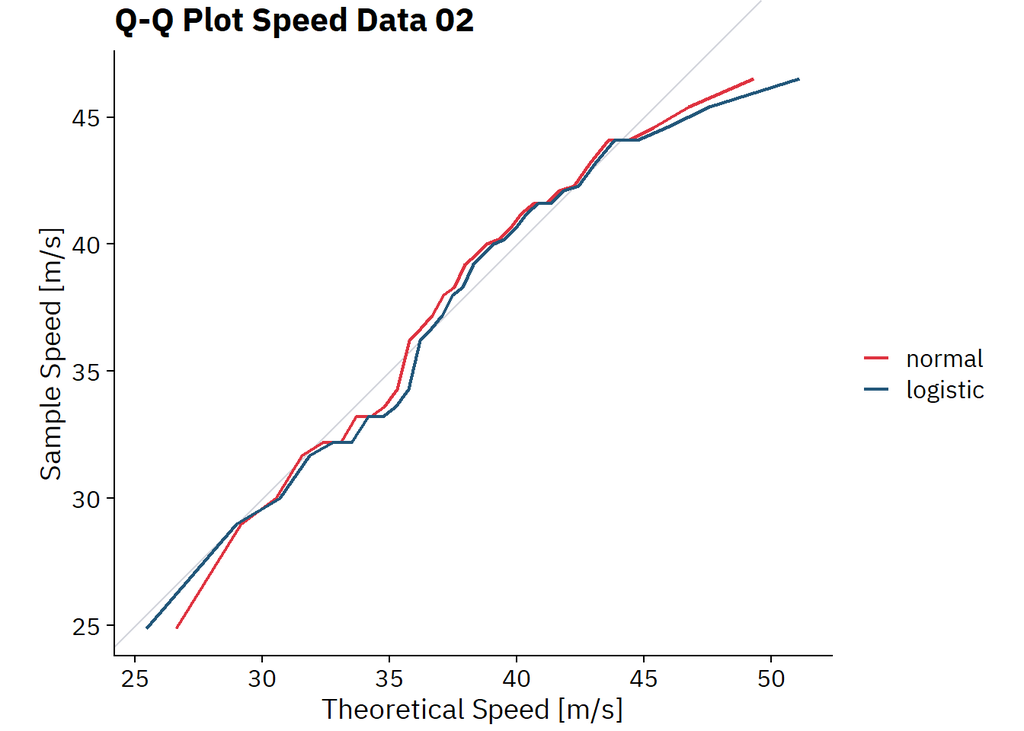

```r
# Q-Q Plot Data02
p4 <- ggplot(data02, aes(sample = speed)) +
  geom_abline(slope = 1, intercept = 0, color = "#d4d6dd") +
  stat_qq(distribution = qnorm,
          dparams = list(norm_fit_speed_data02$estimate[1], norm_fit_speed_data02$estimate[2]),
          geom = "line",
          aes(color = "normal"),
          size = .8) +
  stat_qq(distribution = qlogis,
          dparams = list(logistic_fit_speed_data02$estimate[1], logistic_fit_speed_data02$estimate[2]),
          geom = "line",
          aes(color = "logistic"),
          size = .8) +
  scale_color_manual(name = "",
                     values = c("normal" = "#df3340",
                                "logistic" = "#22577a"),
                     breaks = c("normal",
                                "logistic")) +
  labs(title = "Q-Q Plot Speed Data 02", x = "Theoretical Speed [m/s]", y = "Sample Speed [m/s]") +
  coord_fixed(clip = "off") +
  theme_dviz_open()
p4
```

### 6.2.3 Energy Distribution

Again the differences between our two dataset are quite noticiable. Most rockfalls from heaviest boulders (dataset 01) turn less energy out, max. 50kJ., than the ones from lightest rocks: we find some of them up to 350kJ.

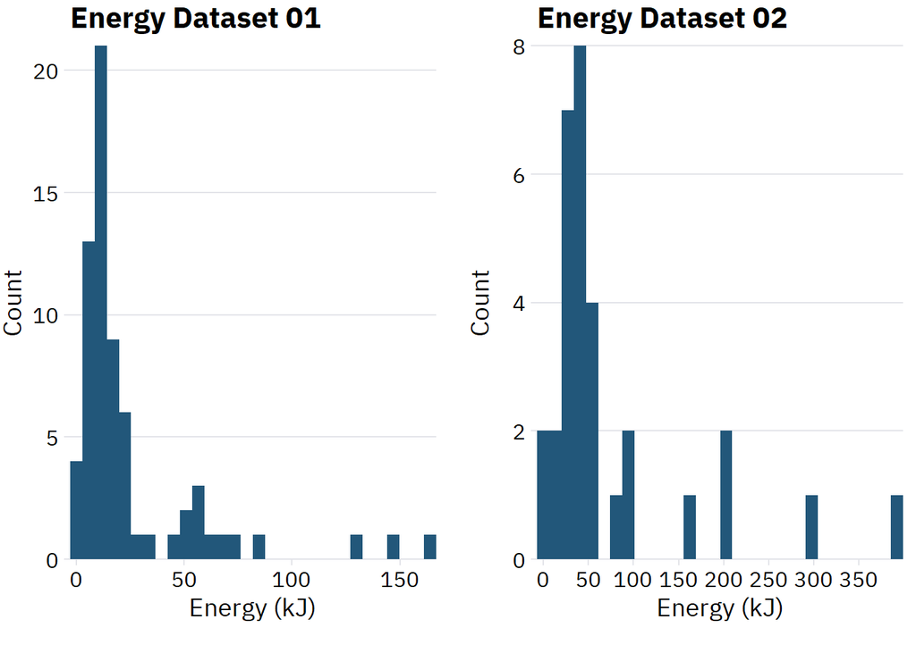

```r
# Chart data01
p1 <- ggplot(data = data01, aes(x = energy_kJ)) +
  geom_histogram(bins = 30, fill = "#22577a") +
  scale_y_continuous(name = "Count", expand = c(0, 0)) +
  scale_x_continuous(name = "Energy (kJ)", breaks = c(seq(0, 200, 50)), expand = c(0, 0)) +
  labs(title = "Energy Dataset 01") +
  coord_cartesian(clip = "off") +
  theme_dviz_hgrid() +
  theme(
    axis.line.x = element_blank(),
    plot.margin = margin(3, 7, 3, 1.5)
  )

# Chart data02
p2 <- ggplot(data = data02, aes(x = energy_kJ)) +
  geom_histogram(bins = 30, fill = "#22577a") +
  scale_y_continuous(name = "Count", expand = c(0, 0)) +
  scale_x_continuous(name = "Energy (kJ)", breaks = c(seq(0, 450, 50)), expand = c(0, 0)) +
  labs(title = "Energy Dataset 02") +
  coord_cartesian(clip = "off") +
  theme_dviz_hgrid() +
  theme(
    axis.line.x = element_blank()
  )

plot_grid(
  p1, NULL, p2,
  NULL, NULL, NULL,
  align = 'hv',
  rel_widths = c(1, .04, 1),
  rel_heights = c(1, .04, 1)
)
```

### 6.2.4 Mass/Speed/Energy relation

Here we show other way what we´ve already noticed above: heavier boulders fall down slower than lighter. Thus, correlation between mass and energy seems to be almost perfect linear. Individual points representation allows us to show how the events (rockfalls) clusters differently around certain x-axis values. In other words, how weight are the falling boulders.

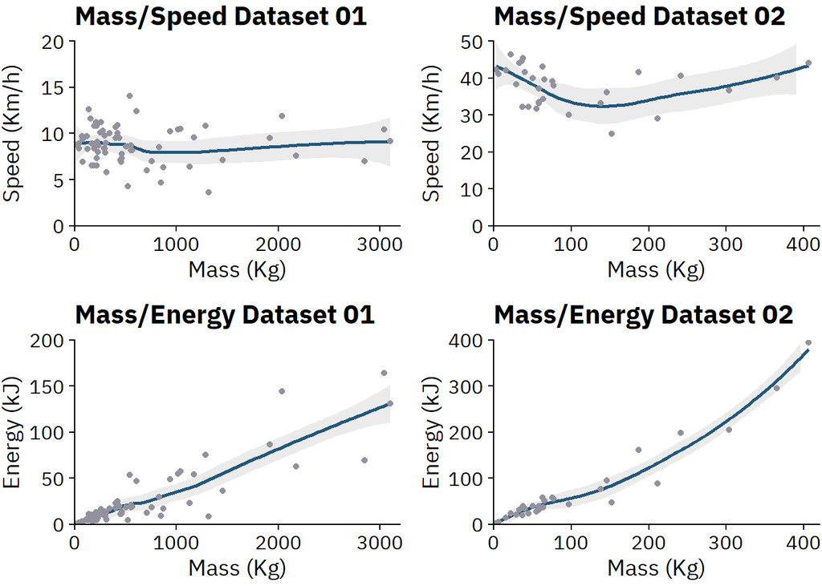

```r
# Chart mass/speed correlation data01
p1 <- ggplot(data = data01, mapping = aes(x = mass, y = speed)) +
  geom_smooth(mapping = aes(x = mass, y = speed), color = "#22577a", alpha = .2) +
  geom_point(color = "#92929e", size = 1.5) +
  scale_x_continuous(
    limits = c(0, 3200),
    expand = c(0, 0),
    name = "Mass (Kg)") +
  scale_y_continuous(
    limits = c(0, 20),
    expand = c(0, 0),
    name = "Speed (Km/h)"
  ) +
  labs(title = "Mass/Speed Dataset 01") +
  theme_dviz_open()

# Chart mass/speed correlation data02
p2 <- ggplot(data = data02, mapping = aes(x = mass, y = speed)) +
  geom_smooth(mapping = aes(x = mass, y = speed), color = "#22577a", alpha = .2) +
  geom_point(color = "#92929e", size = 1.5) +
  scale_x_continuous(
    limits = c(0, 420),
    expand = c(0, 0),
    name = "Mass (Kg)") +
  scale_y_continuous(
    limits = c(0, 50),
    expand = c(0, 0),
    name = "Speed (Km/h)"
  ) +
  labs(title = "Mass/Speed Dataset 02") +
  theme_dviz_open()

# Chart mass/energy correlation data01
p3 <- ggplot(data = data01, mapping = aes(x = mass, y = energy_kJ)) +
  geom_smooth(mapping = aes(x = mass, y = energy_kJ), color = "#22577a", alpha = .2) +
  geom_point(color = "#92929e", size = 1.5) +
  scale_x_continuous(
    limits = c(0, 3200),
    expand = c(0, 0),
    name = "Mass (Kg)") +
  scale_y_continuous(
    limits = c(0, 200),
    expand = c(0, 0),
    name = "Energy (kJ)"
  ) +
  labs(title = "Mass/Energy Dataset 01") +
  theme_dviz_open()

# Chart mass/energy correlation data02
p4 <- ggplot(data = data02, mapping = aes(x = mass, y = energy_kJ)) +
  geom_smooth(mapping = aes(x = mass, y = energy_kJ), color = "#22577a", alpha = .2) +
  geom_point(color = "#92929e", size = 1.5) +
  scale_x_continuous(
    limits = c(0, 420),
    expand = c(0, 0),
    name = "Mass (Kg)") +
  scale_y_continuous(
    limits = c(0, 400),
    expand = c(0, 0),
    name = "Energy (kJ)"
  ) +
  labs(title = "Mass/Energy Dataset 02") +
  theme_dviz_open()

plot_grid(
  p1, NULL, p2,
  NULL, NULL, NULL,
  p3, NULL, p4,
  align = 'hv',
  rel_widths = c(1, .04, 1),
  rel_heights = c(1, .04, 1)
)
```

Let´s bring together all boulders to have an overview.

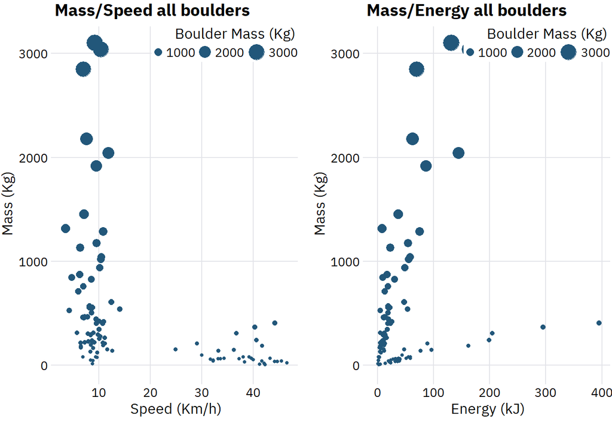

```r
# Merge both datasets in one
df1_df2 <- rbind(data01, data02)

# Mass/Speed scatterplot
p1 <- ggplot(data = df1_df2, aes(x = speed, y = mass, size = mass)) +
  geom_point(color = "#22577a") +
  scale_x_continuous(name = "Speed (Km/h)") +
  scale_y_continuous(name = "Mass (Kg)") +
  scale_radius(
    name = "Boulder Mass (Kg)",
    guide = guide_legend(
      direction = "horizontal",
      title.position = "top",
      title.hjust = 0.9,
      label.position = "right",
      override.aes = list(fill = "#f0f0f2")
    )
  ) +
  labs(title = "Mass/Speed all boulders") +
  theme_dviz_grid(12) +
  theme(
    legend.position = c(1, 0.9),
    legend.justification = c(1, 0),
    legend.spacing.x = unit(2, "pt"),
    legend.spacing.y = unit(2, "pt"),
    legend.background = element_rect(fill = "white", color = NA),
    legend.key.width = unit(10, "pt"),
    strip.text = element_text(size = 12, margin = margin(2, 0, 2, 0)),
    strip.background  = element_rect(
      fill = "#f0f0f2", colour = "#f0f0f2",
      linetype = 1, size = 0.25
    )
  )

# Mass/Energy scatterplot
p2 <- ggplot(data = df1_df2, aes(x = energy_kJ, y = mass, size = mass)) +
  geom_point(color = "#22577a") +
  scale_x_continuous(name = "Energy (kJ)") +
  scale_y_continuous(name = "Mass (Kg)") +
  scale_radius(
    name = "Boulder Mass (Kg)",
    guide = guide_legend(
      direction = "horizontal",
      title.position = "top",
      title.hjust = 0.9,
      label.position = "right",
      override.aes = list(fill = "#f0f0f2")
    )
  ) +
  labs(title = "Mass/Energy all boulders") +
  theme_dviz_grid(12) +
  theme(
    legend.position = c(1, .9),
    legend.justification = c(1, 0),
    legend.spacing.x = unit(2, "pt"),
    legend.spacing.y = unit(2, "pt"),
    legend.background = element_rect(fill = "white", color = NA),
    legend.key.width = unit(10, "pt"),
    strip.text = element_text(size = 12, margin = margin(2, 0, 2, 0)),
    strip.background  = element_rect(
      fill = "#f0f0f2", colour = "#f0f0f2",
      linetype = 1, size = 0.25
    )
  )

plot_grid(
  p1, NULL, p2,
  NULL, NULL, NULL,
  align = 'hv',
  rel_widths = c(1, .04, 1),
  rel_heights = c(1, .04, 1)
)
```

### 6.2.5 Rockfalls per Hour

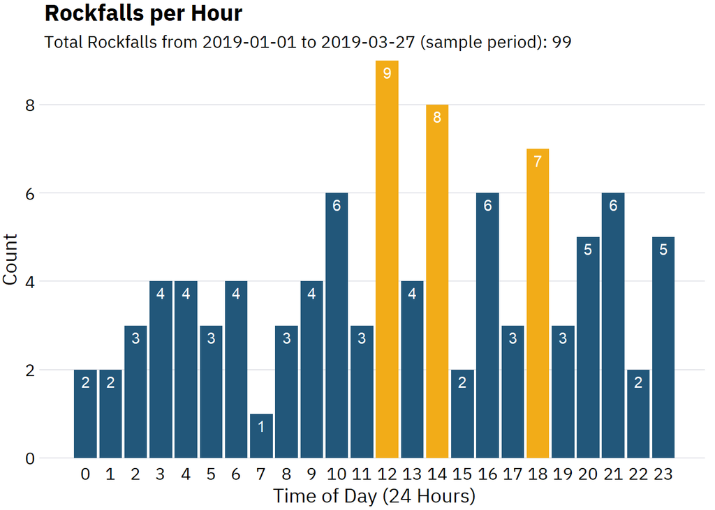

```r
# Count rockfalls per hour
rockfalls_hour <- count(df1_df2, time)
rockfalls_hour_hightlight <- rockfalls_hour %>%
  mutate(tohighlight = ifelse(n %in% c(9, 8, 7), "yes", "no"))

# Total rockfalls per day
total_rockfalls <- sum(rockfalls_hour$n)

p <- ggplot(data = rockfalls_hour_hightlight, aes(x = time, y = n, fill = tohighlight)) +
  geom_col(fill = "#22577a", alpha = 0.9) +
  scale_y_continuous(name = "Count",
                     expand = c(0, 0),
                     breaks = c(seq(0, 8, 2))) +
  geom_col(aes(fill = tohighlight)) +
  scale_fill_manual(
    values = c("#22577a", "#f2ac18"),
    guide = FALSE
    ) +
  scale_x_time(
    name = "Time of Day (24 Hours)",
    position = "bottom",
    breaks = unique(rockfalls_hour_hightlight$time),
    labels = c("0", "1", "2", "3", "4", "5", "6", "7", "8", "9", "10", "11", "12", "13", "14", "15", "16", "17", "18", "19", "20", "21", "22", "23")
  ) +
  geom_text(aes(label=n), vjust=1.5, colour="white") +
  labs(title = "Rockfalls per Hour", subtitle = paste("Total Rockfalls from 2019-01-01 to 2019-03-27 (sample period):", total_rockfalls)) +
  coord_cartesian(clip = "off") +
  theme_dviz_hgrid() +
  theme(
    axis.ticks.x = element_blank(),
    axis.line = element_blank(),
    plot.margin = margin(3, 7, 3, 1.5)
  )
p
```

### 6.2.6 Traffic Density per Hour

Together with our rockfalls characteristics variables (mass, speed, enery and time), we need to consider data regarding the traffic density in order to carry our next probability calculations out. As the chart show us, no surprisingly the busiest traffic hours are between 16 and 19 pm.

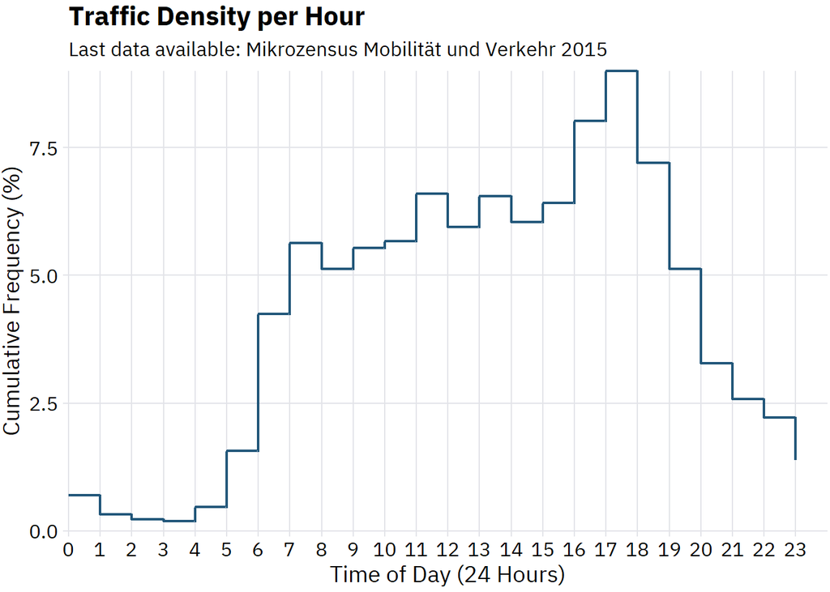

```r
p <- ggplot(data = data_traffic) +
  geom_step(
    mapping = aes(x = hour, y = pct_traffic),
    color = "#22577a",
    size = 0.75
  ) +
  scale_x_continuous(
    name = "Time of Day (24 Hours)",
    limits = c(0, 24),
    expand = c(0, 0),
    breaks = unique(data_traffic$hour)
  ) +
  scale_y_continuous(
    name = "Cumulative Frequency (%)",
    expand = c(0, 0),
    limits = c(0, 9)
  ) +
  labs(title = "Traffic Density per Hour", subtitle = "Last data available: Mikrozensus Mobilität und Verkehr 2015") +
  coord_cartesian(clip = "off") +
  theme_dviz_grid() +
  theme(axis.line.x = element_blank())
p
```

# 7 Probability

## 7.1 Setting the Scene

First, we need to set up our scenario:

Given: * Draped mesh fails stopping a rockfall event. * Boulder mass over 2000 Kg. * Cars per hour at danger area: 16’573 cars within 24 hours; steady traffic flow over the day without traffic jams. * Speed of cars: 60 Km/h or 16.66 m/s. * Average [size of car](http://eupocketbook.org/tables/): * Length: 4.2m * Width: 1.8m

Premises: * Boulders´ width and volume aren´t taking into account (=0). * Car accidents caused by falling boulders (only +2000 Kg.) are always deadly. * Only cars´ length is taking into consideration. * Boulders´ energy (mass + speed) isn´t taking into account. Only the biggest boulders (+2000 Kg.) reach the road. * For probability calculations a car would be hit by a falling boulder, we´re just taking into consideration the exactly moment when one boulder reachs the road.

Hypothesis: A rockfall event happens, goes through the draped mesh and hits a car.

## 7.2 Rockfall Probability per Hour

First, we want to know the probability of a rockfall takes place during the day.

```r
# Calculate expected value at a certain hour
(rockfalls_ev <- mutate(rockfalls_hour, exp_val_rockfall = n / 0.99 / 100))
```

| time | n | exp_val_rockfall |
| --- | --- | --- |
| 00:00:00 | 2 | 0.0202020 |
| 01:00:00 | 2 | 0.0202020 |
| 02:00:00 | 3 | 0.0303030 |
| 03:00:00 | 4 | 0.0404040 |
| 04:00:00 | 4 | 0.0404040 |
| 05:00:00 | 3 | 0.0303030 |
| 06:00:00 | 4 | 0.0404040 |
| 07:00:00 | 1 | 0.0101010 |
| 08:00:00 | 3 | 0.0303030 |
| 09:00:00 | 4 | 0.0404040 |
| 10:00:00 | 6 | 0.0606061 |
| 11:00:00 | 3 | 0.0303030 |
| 12:00:00 | 9 | 0.0909091 |
| 13:00:00 | 4 | 0.0404040 |
| 14:00:00 | 8 | 0.0808081 |
| 15:00:00 | 2 | 0.0202020 |
| 16:00:00 | 6 | 0.0606061 |
| 17:00:00 | 3 | 0.0303030 |
| 18:00:00 | 7 | 0.0707071 |
| 19:00:00 | 3 | 0.0303030 |
| 20:00:00 | 5 | 0.0505051 |
| 21:00:00 | 6 | 0.0606061 |
| 22:00:00 | 2 | 0.0202020 |
| 23:00:00 | 5 | 0.0505051 |

```r
# Let´s double check our results
sum(rockfalls_ev$exp_val_rockfall) # must be 1
```

```
## [1] 1
```

```r
sum(rockfalls_ev$n) # must be 99 (total of events registered in our sample)
```

```
## [1] 99
```

## 7.3 Danger Area

Considering our premises as starting point for our probability calculations, now we´re taking care of the time that a car remains in the so called danger area. In order to do that, we´re making use of car average speed and length and average width of boulders.

```r
# Total time (in seconds) one car remains in the danger area: distance (average car length) / speed (average speed 60 Km/h or 16.66 m/s)
time_car_da = 4.2 / 16.66

# Now that we have the total time a car remains in the danger area, we want to make this same calculation
# for all cars passing throught this zone during the day
total_car_per_hour <- mutate(
  data_traffic,
  cars_danger_zone_per_hour = pct_traffic * 165.73,
  time_danger_zone_seconds = cars_danger_zone_per_hour * time_car_da,
  exp_val_car_per_hour = time_danger_zone_seconds / 3600
)

# Now we calculate the expected value of a car getting hit by a boulder at a certain time
(
  exp_val_car_hit <- mutate(
    rockfalls_ev,
    events = rockfalls_ev$n,
    hour = total_car_per_hour$hour,
    cars_danger_zone_per_hour = total_car_per_hour$cars_danger_zone_per_hour,
    time_danger_zone_seconds = total_car_per_hour$time_danger_zone_seconds,
    exp_val_car = total_car_per_hour$exp_val_car_per_hour,
    total_exp_val = exp_val_rockfall * total_car_per_hour$exp_val_car_per_hour
  ) %>% # reorder the columns
    dplyr::select(
      hour,
      events,
      cars_danger_zone_per_hour,
      time_danger_zone_seconds,
      exp_val_car,
      exp_val_rockfall,
      total_exp_val
    )
)
```

| hour | events | cars_danger_zone_per_hour | time_danger_zone_seconds | exp_val_car | exp_val_rockfall | total_exp_val |
| --- | --- | --- | --- | --- | --- | --- |
| 0 | 2 | 114.66559 | 28.907292 | 0.0080298 | 0.0202020 | 0.0001622 |
| 1 | 2 | 53.51061 | 13.490070 | 0.0037472 | 0.0202020 | 0.0000757 |
| 2 | 3 | 38.22186 | 9.635764 | 0.0026766 | 0.0303030 | 0.0000811 |
| 3 | 4 | 30.57749 | 7.708611 | 0.0021413 | 0.0404040 | 0.0000865 |
| 4 | 4 | 76.44373 | 19.271528 | 0.0053532 | 0.0404040 | 0.0002163 |
| 5 | 3 | 259.90867 | 65.523195 | 0.0182009 | 0.0303030 | 0.0005515 |
| 6 | 4 | 703.28229 | 177.298056 | 0.0492495 | 0.0404040 | 0.0019899 |
| 7 | 1 | 932.61347 | 235.112639 | 0.0653091 | 0.0101010 | 0.0006597 |
| 8 | 3 | 848.52537 | 213.913959 | 0.0594205 | 0.0303030 | 0.0018006 |
| 9 | 4 | 917.32472 | 231.258334 | 0.0642384 | 0.0404040 | 0.0025955 |
| 10 | 6 | 940.25784 | 237.039792 | 0.0658444 | 0.0606061 | 0.0039906 |
| 11 | 3 | 1093.14530 | 275.582848 | 0.0765508 | 0.0303030 | 0.0023197 |
| 12 | 9 | 986.12408 | 248.602709 | 0.0690563 | 0.0909091 | 0.0062778 |
| 13 | 4 | 1085.50092 | 273.655695 | 0.0760155 | 0.0404040 | 0.0030713 |
| 14 | 8 | 1001.41282 | 252.457014 | 0.0701269 | 0.0808081 | 0.0056668 |
| 15 | 2 | 1062.56780 | 267.874236 | 0.0744095 | 0.0202020 | 0.0015032 |
| 16 | 6 | 1330.12085 | 335.324584 | 0.0931457 | 0.0606061 | 0.0056452 |
| 17 | 3 | 1490.65268 | 375.794792 | 0.1043874 | 0.0303030 | 0.0031633 |
| 18 | 7 | 1192.52214 | 300.635834 | 0.0835100 | 0.0707071 | 0.0059047 |
| 19 | 3 | 848.52537 | 213.913959 | 0.0594205 | 0.0303030 | 0.0018006 |
| 20 | 5 | 542.75046 | 136.827847 | 0.0380077 | 0.0505051 | 0.0019196 |
| 21 | 6 | 428.08487 | 107.920556 | 0.0299779 | 0.0606061 | 0.0018168 |
| 22 | 2 | 366.92989 | 92.503333 | 0.0256954 | 0.0202020 | 0.0005191 |
| 23 | 5 | 229.33118 | 57.814583 | 0.0160596 | 0.0505051 | 0.0008111 |

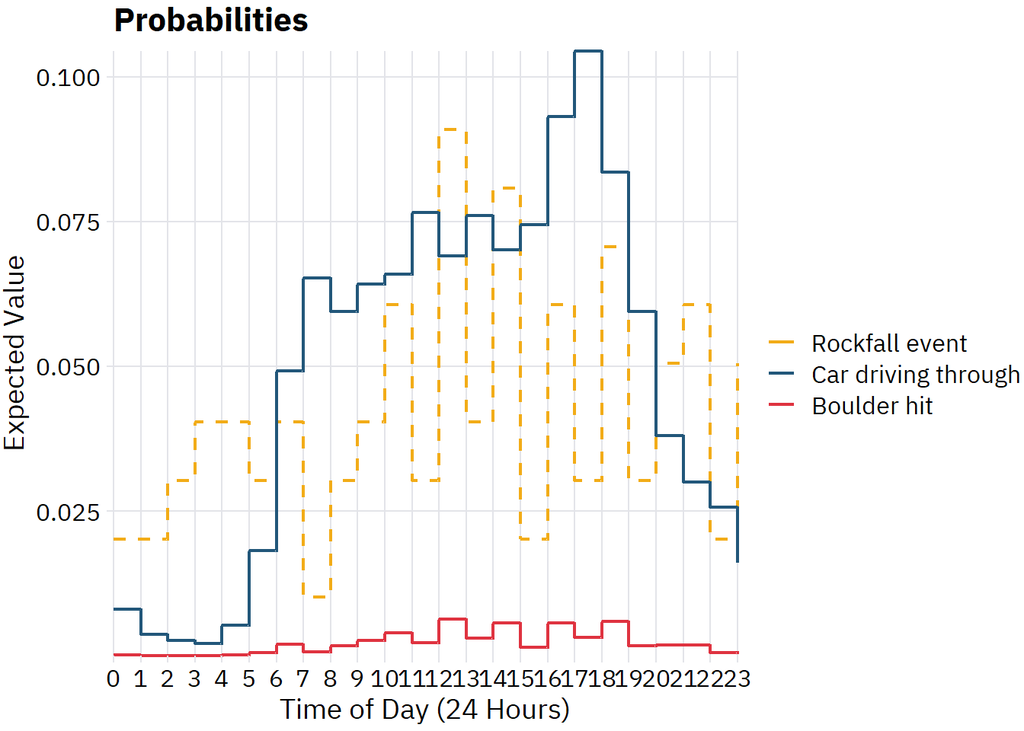

```r
# Plotting our results
p <- ggplot(data = exp_val_car_hit) +
  geom_step(
    mapping = aes(x = hour, y = exp_val_rockfall, color = "Rockfall event"),
    size = 0.75,
    linetype = "dashed"
  ) +
  geom_step(
    mapping = aes(x = hour, y = exp_val_car, color = "Car driving through"),
    size = 0.75
  ) +
  geom_step(
    mapping = aes(x = hour, y = total_exp_val, color = "Boulder hit"),
    size = 0.75
  ) +
  scale_x_continuous(
    name = "Time of Day (24 Hours)",
    expand = c(0, 0),
    breaks = unique(exp_val_car_hit$hour)
  ) +
  scale_y_continuous(
    name = "Expected Value",
    expand = c(0, 0),
  ) +
  scale_color_manual(name = "",
                   values = c("Rockfall event" = "#f2ac18",
                              "Car driving through" = "#22577a",
                              "Boulder hit" = "#df3340"),
                   breaks = c("Rockfall event",
                              "Car driving through",
                              "Boulder hit")) +
  labs(title = "Probabilities") +
  coord_cartesian(clip = "off") +
  theme_dviz_grid() +
  theme(axis.line.x = element_blank()
)
p
```

## 7.4 Probability of a Car Hit

After our data analysis and probability calculations, we end that the expected value of a car getting hit by a boulder at a certain point is as follows:

```r
# Showing final probability result
prob_car_hit <- sum(exp_val_car_hit$total_exp_val)
cat("The probability of a car getting hit by a falling boulder when it goes through the draped mesh and hits a car is:", prob_car_hit)
```

```
## The probability of a car getting hit by a falling boulder when it goes through the draped mesh and hits a car is: 0.05262901
```

```r
# Create a .csv file as output file for replication and further analysis
# write_csv(exp_val_car_hit, "output/probability_car_hit.csv") # uncomment to create the file
```

# 8 Monte-Carlo Simulation

In order to select random samples from our probability distribution, we´re gonna make use of a Monte-Carlo Simulation. In our case, we want to build a Monte-Carlo simulation to count how many times a falling boulder goes through the draped mesh and hits a car taking into account numerous one-year simulations. Then we´re gonna to compare them each other.

To do that, three variables are created and measured:

```r
# Setting global variables
mass_in_net <- 0
num_boulder_through_net <- 0
car_hit_stat <- 0
car_hit_mean <- 0
car_hit_max <- 0
events_current_year <- 0

# Falling boulder event
boulder_event <- function(speed, mass) {
  mass_in_net
  num_boulder_through_net
  broken <- FALSE
  energy <- (.5 * mass * (speed ** 2)) / 1000
  if (energy >= 1000) {
    broken <- TRUE
  } else if (energy >= 500) {
    if (mass_in_net >= 2000) {
      broken <- TRUE
    }
  }
  if (broken) {
    num_boulder_through_net <-  num_boulder_through_net + 1
    events_current_year <- events_current_year + 1
  }
  mass_in_net  <-  mass_in_net + mass
  return(broken)
}

# Draped mesh clearing
net_clearing_process <- function(now, event_time_delta, clearing_time_minute, day_minutes) {
  mass_in_net
  current_time <- now %% day_minutes
  event_time = current_time + event_time_delta
  if (current_time < clearing_time_minute) {
    if (event_time >= clearing_time_minute) {
      mass_in_net <- 0
    }
  } else {
    if (event_time >= (day_minutes + clearing_time_minute))
      mass_in_net <- 0
  }
}

# Car hit
car_hitting <- function(event_time, day_minutes) {
  car_hit_stat
  car_hit_mean
  car_hit_max
  current_time <- event_time %% day_minutes
  current_hour <- base::floor(current_time / 60)
  if (current_hour == 0) {
    current_hour = 24
  }
  hit_number <- runif(1, min = 0, max = 1)
  if (hit_number <= exp_val_car_hit$exp_val_car[current_hour]) {
     car_hit_stat <- car_hit_stat + 1
  }
  if (hit_number <= 0.04835726) {
    car_hit_mean <- car_hit_mean + 1
  }
  if (hit_number <= 0.104387442) {
    car_hit_max <- car_hit_max + 1
  }
}

# Monte-Carlo simulation
monte_carlo_rockfall <- function(num_of_years, clearing_time_hour) {
  mass_in_net <- 0
  day_minutes <- 24 * 60
  year_minutes <- day_minutes * 365
  clearing_time_minute <- clearing_time_hour * 60

  for (year in 1:num_of_years) {
    current_year <- year
    events_current_year <- 0
    mass_in_net <- 0
    now <- 0
    time_to_next_event_data01 <- 3732
    time_to_next_event_data02 <- 3892
    while (now < year_minutes) {
      if (time_to_next_event_data01 < time_to_next_event_data02) {
      net_clearing_process(now, time_to_next_event_data01, clearing_time_minute, day_minutes)
      time_to_next_event_data02 <- time_to_next_event_data02 - time_to_next_event_data01
      now <- now + time_to_next_event_data01
      time_to_next_event_data01 <- 3746
      speed_1 <- rnorm(1, mean = norm_fit_speed_data01$estimate[1], sd = norm_fit_speed_data01$estimate[2])
      mass_1 <- rlnorm(1, meanlog = lognorm_fit_mass_data01$estimate[1], sdlog = lognorm_fit_mass_data01$estimate[2])
      broken <- boulder_event(speed_1, mass_1)
      if (broken) {
        car_hitting(now, day_minutes)
        break
        }
      }
      else {
        net_clearing_process(now, time_to_next_event_data02, clearing_time_minute, day_minutes)
        time_to_next_event_data01 <- time_to_next_event_data01 - time_to_next_event_data02
        now <- now + time_to_next_event_data02
        time_to_next_event_data02 <- 3864
        speed_2 <- rnorm(1, mean = norm_fit_speed_data02$estimate[1], sd = norm_fit_speed_data02$estimate[2])
        mass_2 <- rexp(1, rate = expo_fit_mass_data02$estimate[1])
        broken <- boulder_event(speed_2, mass_2)
        if (broken){
          car_hitting(now, day_minutes)
          break
        }
      }
    }
  }

  prob_boulder_through_net_mc <- num_boulder_through_net / num_of_years
  prob_car_hit_stat_mc <- car_hit_stat / num_of_years
  prob_car_hit_mean_mc <- car_hit_mean / num_of_years
  prob_car_hit_max_mc <- car_hit_max / num_of_years

  df <- data.frame(
                   'num_boulder_through_net' = num_boulder_through_net,
                   'prob_boulder_through_net_mc' = prob_boulder_through_net_mc,
                   'car_hit_stat' = car_hit_stat,
                   'prob_car_hit_stat_mc' = prob_car_hit_stat_mc,
                   'car_hit_mean' = car_hit_mean,
                   'prob_car_hit_mean_mc' = prob_car_hit_mean_mc,
                   'car_hit_max' = car_hit_max,
                   'prob_car_hit_max_mc' = prob_car_hit_max_mc,
                   'num_of_years' = num_of_years
                   )
  return(df)
}
```

```r
monte_carlo_rockfall(num_of_years = 100, clearing_time_hour = 8)
```

| num_boulder_through_net | prob_boulder_through_net_mc | car_hit_stat | prob_car_hit_stat_mc | car_hit_mean | prob_car_hit_mean_mc | car_hit_max | prob_car_hit_max_mc | num_of_years |
| --- | --- | --- | --- | --- | --- | --- | --- | --- |
| 0 | 0 | 0 | 0 | 0 | 0 | 0 | 0 | 100 |

# 9 Linting

The code in this RMarkdown is linted with the [lintr package](https://github.com/jimhester/lintr), which is based on the [tidyverse style guide](http://style.tidyverse.org/).

```r
lintr::lint("main.Rmd", linters =
              lintr::with_defaults(
                commented_code_linter = NULL,
                trailing_whitespace_linter = NULL
                )
            )
# if you have additional scripts and want them to be linted too, add them here
# lintr::lint("scripts/my_script.R")
```